# STAT4051_hw7_wrh

Ruohan wang

2019/4/24

```r
library(faraway)
library(lmerTest)
library(lme4)
library(nlme)
```

```r
library(ggplot2)
library(dplyr)
library(reshape)
```

1(a)

```r
data1 =  read.csv("~/downloads/femalestress.csv")

head(data1)
```

```
##   subject week.0 week.1 week.2 week.3
## 1       1     16     22     23     25
## 2       2     12     18     24     29
## 3       3     23     24     26     27
## 4       4      8     20     28     30
## 5       5      3     12     13     17
## 6       6      5     13     11     15
```

```r
#Because it is wide we transfer to long
#stress.long= reshape(data1, direction="long",idvar="subject", vary=c("week.0","week.1","week.2","week.3"),v.names ="stresslevel",variable.name = "weeks")
stress.long = melt(data1 ,id.vars=c("subject"),measure.vars =c("week.0","week.1","week.2","week.3"),value.name="stresslevel",variable.name ="week")
str(stress.long)
```

```
## 'data.frame':    60 obs. of  3 variables:
##  $ subject : int  1 2 3 4 5 6 7 8 9 10 ...
##  $ variable: Factor w/ 4 levels "week.0","week.1",..: 1 1 1 1 1 1 1 1 1 1 ...
##  $ value   : int  16 12 23 8 3 5 19 22 12 16 ...
```

```r
#convert week to numeric
stress.long$variable = as.numeric(stress.long$variable)
#subject factor
stress.long$subject = as.factor(data1$subject)
head(stress.long)
```

```
##   subject variable value
## 1       1        1    16
## 2       2        1    12
## 3       3        1    23
## 4       4        1     8
## 5       5        1     3
## 6       6        1     5
```

```r
library(lattice)
```

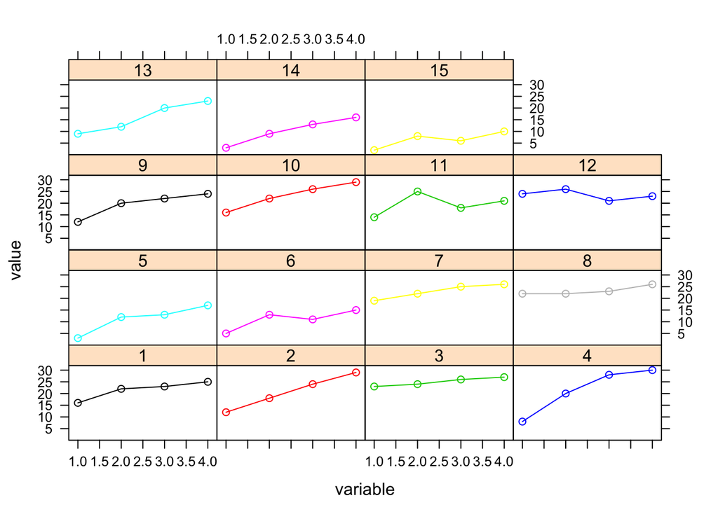

```r
#xyplot(stresslevel~week,data=stress.long,groups=subject,type='o',col=as.factor(stress.long$subject),panel=panel.superpose)
xyplot(value~variable|as.factor(subject),data=stress.long, groups=subject,type='o',col=as.factor(stress.long$subject),panel=panel.superpose,layout=c(4,4))
```

From the multi-panel conditional plot illustrating each subject???s improvement. Subject 4 is increasing most and 12 is increasing least, even less after that.

1.(b)

```r
modellm = lm(value ~ variable,data=stress.long)
summary(modellm)
```

```
##
## Call:
## lm(formula = value ~ variable, data = stress.long)
##
## Residuals:
##     Min      1Q  Median      3Q     Max
## -13.993  -4.968   1.507   5.227  10.447
##
## Coefficients:
##             Estimate Std. Error t value Pr(>|t|)
## (Intercept)  10.3333     2.0319   5.086 4.12e-06 ***
## variable      3.2200     0.7419   4.340 5.78e-05 ***
## ---
## Signif. codes:  0 '***' 0.001 '**' 0.01 '*' 0.05 '.' 0.1 ' ' 1
##
## Residual standard error: 6.425 on 58 degrees of freedom
## Multiple R-squared:  0.2451, Adjusted R-squared:  0.2321
## F-statistic: 18.84 on 1 and 58 DF,  p-value: 5.777e-05
```

p is very significant. In linear model, all the properties of linear model exists. Naive Approach All Observations are INDEPENDENT.

1(c)

```r
#no interactions, random intercept
model_randomi = lmer(value ~ variable + (1|subject),data=stress.long)
summary(model_randomi)
```

```
## Linear mixed model fit by REML. t-tests use Satterthwaite's method [
## lmerModLmerTest]
## Formula: value ~ variable + (1 | subject)
##    Data: stress.long
##
## REML criterion at convergence: 344.9
##
## Scaled residuals:
##      Min       1Q   Median       3Q      Max
## -2.62034 -0.64678  0.00136  0.56508  2.23426
##
## Random effects:
##  Groups   Name        Variance Std.Dev.
##  subject  (Intercept) 32.02    5.659
##  Residual             10.37    3.220
## Number of obs: 60, groups:  subject, 15
##
## Fixed effects:
##             Estimate Std. Error      df t value Pr(>|t|)
## (Intercept)  10.3333     1.7809 25.3148   5.802 4.54e-06 ***
## variable      3.2200     0.3718 44.0000   8.661 4.63e-11 ***
## ---
## Signif. codes:  0 '***' 0.001 '**' 0.01 '*' 0.05 '.' 0.1 ' ' 1
##
## Correlation of Fixed Effects:
##          (Intr)
## variable -0.522
```

```r
#random intercept and random slope
model_randomis = lmer(value ~ variable + (1+variable|subject),data=stress.long)
summary(model_randomis)
```

```
## Linear mixed model fit by REML. t-tests use Satterthwaite's method [
## lmerModLmerTest]
## Formula: value ~ variable + (1 + variable | subject)
##    Data: stress.long
##
## REML criterion at convergence: 334.6
##
## Scaled residuals:
##      Min       1Q   Median       3Q      Max
## -1.68862 -0.44432 -0.06432  0.38149  2.78422
##
## Random effects:
##  Groups   Name        Variance Std.Dev. Corr
##  subject  (Intercept) 63.648   7.978
##           variable     3.157   1.777    -0.71
##  Residual              5.344   2.312
## Number of obs: 60, groups:  subject, 15
##
## Fixed effects:
##             Estimate Std. Error      df t value Pr(>|t|)
## (Intercept)  10.3333     2.1858 14.0008   4.728 0.000324 ***
## variable      3.2200     0.5308 13.9985   6.067  2.9e-05 ***
## ---
## Signif. codes:  0 '***' 0.001 '**' 0.01 '*' 0.05 '.' 0.1 ' ' 1
##
## Correlation of Fixed Effects:
##          (Intr)
## variable -0.729
```

```r
#compare
anova(model_randomi,model_randomis)
```

```
## refitting model(s) with ML (instead of REML)
```

```
## Data: stress.long
## Models:
## model_randomi: value ~ variable + (1 | subject)
## model_randomis: value ~ variable + (1 + variable | subject)
##                Df    AIC    BIC  logLik deviance  Chisq Chi Df Pr(>Chisq)
## model_randomi   4 355.42 363.80 -173.71   347.42
## model_randomis  6 349.73 362.29 -168.86   337.73 9.6948      2   0.007849
##
## model_randomi
## model_randomis **
## ---
## Signif. codes:  0 '***' 0.001 '**' 0.01 '*' 0.05 '.' 0.1 ' ' 1
```

compare the AIC and the BIC ,we have that the smaller one is better.so we choose the model : model_randomis = lmer(stresslevel ~ week + (1+week|subject),data=stress.long)

1(d)

```r
summary(modellm)
```

```
##
## Call:
## lm(formula = value ~ variable, data = stress.long)
##
## Residuals:
##     Min      1Q  Median      3Q     Max
## -13.993  -4.968   1.507   5.227  10.447
##
## Coefficients:
##             Estimate Std. Error t value Pr(>|t|)
## (Intercept)  10.3333     2.0319   5.086 4.12e-06 ***
## variable      3.2200     0.7419   4.340 5.78e-05 ***
## ---
## Signif. codes:  0 '***' 0.001 '**' 0.01 '*' 0.05 '.' 0.1 ' ' 1
##
## Residual standard error: 6.425 on 58 degrees of freedom
## Multiple R-squared:  0.2451, Adjusted R-squared:  0.2321
## F-statistic: 18.84 on 1 and 58 DF,  p-value: 5.777e-05
```

```r
summary(model_randomis)
```

```
## Linear mixed model fit by REML. t-tests use Satterthwaite's method [
## lmerModLmerTest]
## Formula: value ~ variable + (1 + variable | subject)
##    Data: stress.long
##
## REML criterion at convergence: 334.6
##
## Scaled residuals:
##      Min       1Q   Median       3Q      Max
## -1.68862 -0.44432 -0.06432  0.38149  2.78422
##
## Random effects:
##  Groups   Name        Variance Std.Dev. Corr
##  subject  (Intercept) 63.648   7.978
##           variable     3.157   1.777    -0.71
##  Residual              5.344   2.312
## Number of obs: 60, groups:  subject, 15
##
## Fixed effects:
##             Estimate Std. Error      df t value Pr(>|t|)
## (Intercept)  10.3333     2.1858 14.0008   4.728 0.000324 ***
## variable      3.2200     0.5308 13.9985   6.067  2.9e-05 ***
## ---
## Signif. codes:  0 '***' 0.001 '**' 0.01 '*' 0.05 '.' 0.1 ' ' 1
##
## Correlation of Fixed Effects:
##          (Intr)
## variable -0.729
```

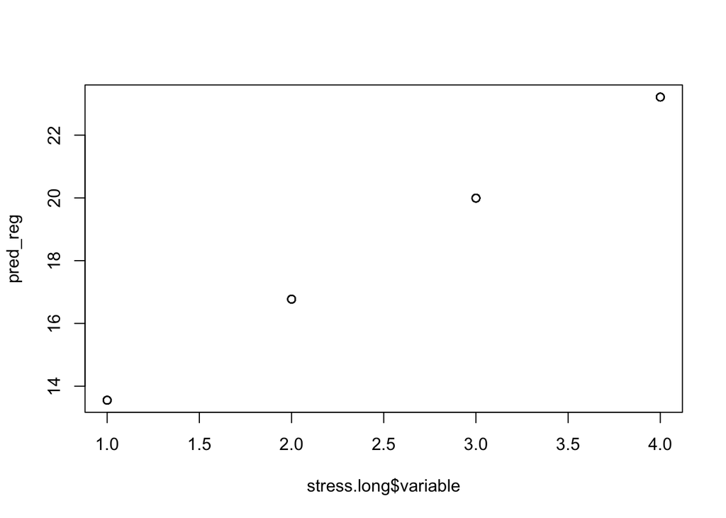

```r
#m_reg plot
pred_reg=predict(modellm)
plot(pred_reg~stress.long$variable)
```

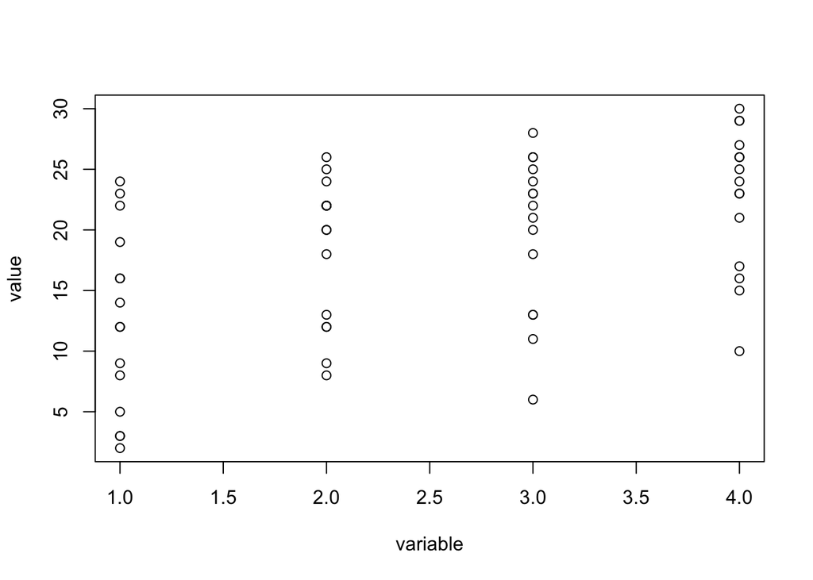

```r
#m_randint plot
pred_randint=predict(model_randomis)
plot(value~variable,data=stress.long)
```

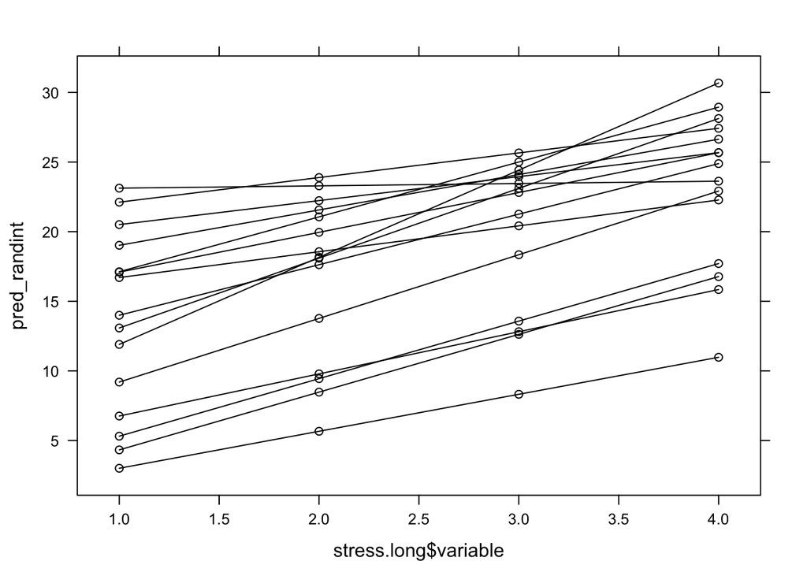

```r
library(lattice)
xyplot(pred_randint~stress.long$variable,groups=subject,type="o",col="black",data=stress.long)
```

So I use the way listed in lab to compare and contrast your results from part b and c. in words and graphics. From xyplot, we can see the distribution of all the lines.

1(e)

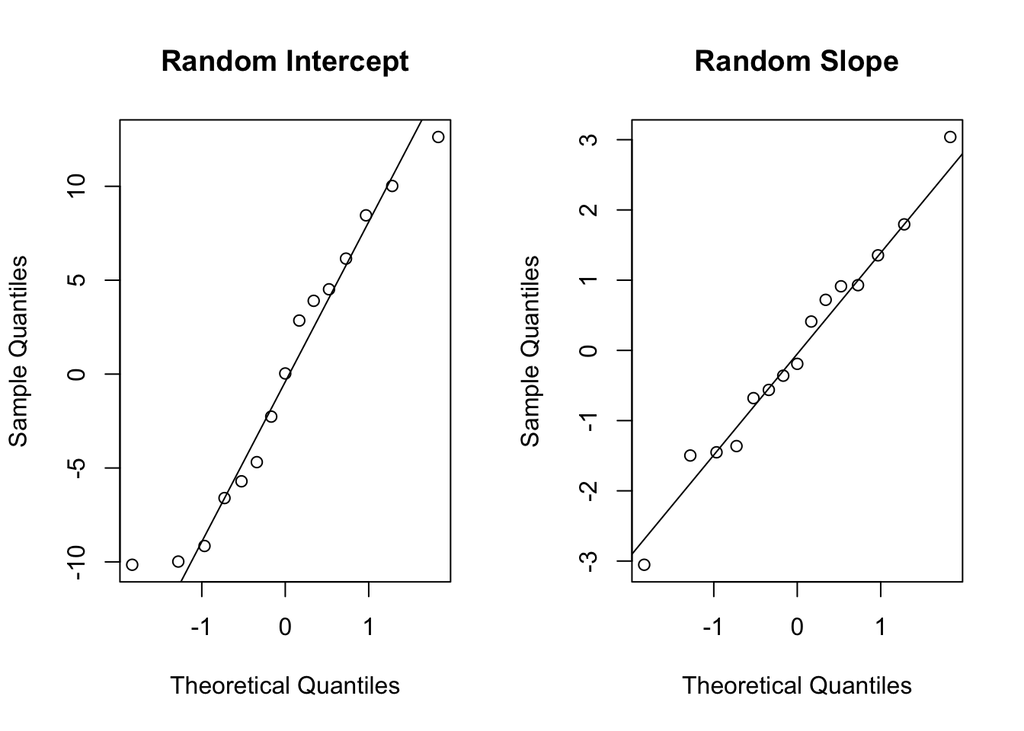

```r
#assumotions check
# model_randomis<-lmer(stresslevel ~ week + (1+week|subject),data=stress.long)
par (mfrow= c(1,2))
# Random Intercept
qqnorm(ranef(model_randomis)$subject[["(Intercept)"]],main="Random Intercept")
qqline(ranef(model_randomis)$subject[["(Intercept)"]])
# Random Slope
qqnorm(ranef(model_randomis)$subject[["variable"]],main="Random Slope")
qqline(ranef(model_randomis)$subject[["variable"]])
```

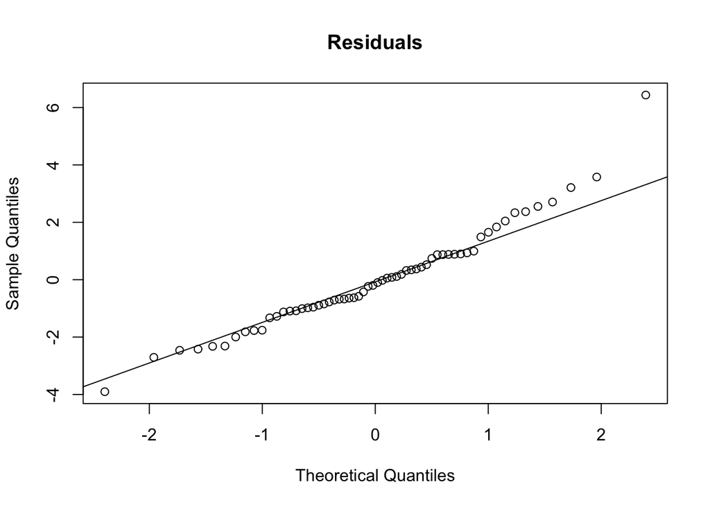

```r
#Residuals
par(mfrow=c(1,1))
Residuals<-residuals(model_randomis)
qqnorm(Residuals,main="Residuals")
qqline(Residuals)
```

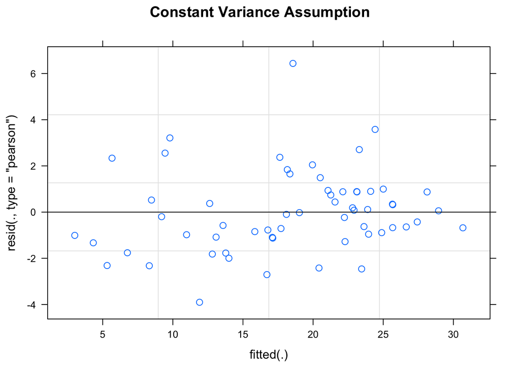

```r
#constant variance
plot(model_randomis,main="Constant Variance Assumption")
```

The independent, constant var and normal residuals all fit. So assumptions checked well.

1(f)

```r
ranef(model_randomis)
```

```
## $subject
##     (Intercept)   variable
## 1    3.90199756 -0.3604321
## 2   -2.26391734  1.7945927
## 3   10.01757549 -1.4512007
## 4   -4.68838551  3.0387709
## 5   -9.15247535  0.9126728
## 6   -6.60134302 -0.1917467
## 7    6.14946461 -0.6801129
## 8    8.45376619 -1.4969822
## 9    0.03388668  0.4106556
## 10   2.85134245  0.7198894
## 11   4.51582567 -1.3628417
## 12  12.62554234 -3.0528086
## 13  -5.70819634  1.3536327
## 14 -10.15279350  0.9287381
## 15  -9.98228994 -0.5628272
##
## with conditional variances for "subject"
```

```r
#because it is 15 obs total, so 1st female is 1,16,31,46,plus 15 each
predict(model_randomis)[c(1,16,31,46)]
```

```
##        1       16       31       46
## 17.09490 19.95447 22.81403 25.67360
```

```r
#x=-0.3604321*3+ 3.90199756 + 10.3333 + 3.2200 *3
#x
```

Because this is random slope & intercept model so we need to compute all four model to get specific value:

f1.week0 = -0.3604321*1+ 3.2200* 1+ 3.90199756 + 10.3333 = 17.09487

f1.week1 = -0.3604321*2+ 3.2200* 2+ 3.90199756 + 10.3333= 19.95443

f1.week2= -0.3604321*3+ 3.2200* 3+ 3.90199756 + 10.3333 = 22.814

f1.week3 = -0.3604321*4+ 3.2200* 4+ 3.90199756 + 10.3333= 25.67357

Fit with conditional variances for ???subject???

2(a)

```r
library(foreign)
cholesterol<- read.dta("~/downloads/cholesterol.dta")
colnames(cholesterol)<-c("treatment", "id", "month.0", "month.6", "month.12", "month.20", "month.24")

#treatment = 1 chenodiol
#treatment = 2 placebo
attach(cholesterol)
head(cholesterol)
```

```
##   treatment id month.0 month.6 month.12 month.20 month.24
## 1         1  1     178     246      295      228      274
## 2         1  2     254     260      278      245      340
## 3         1  3     185     232      215      220      292
## 4         1  4     219     268      241      260      320
## 5         1  5     205     232      265      242      230
## 6         1  6     182     213      173      200      193
```

```r
#already wide format
cov(cholesterol[,-c(1,2)], use="complete")
```

```
##           month.0  month.6 month.12 month.20 month.24
## month.0  2465.471 1739.771 1571.466 1619.963 1485.656
## month.6  1739.771 2172.061 1628.873 1616.135 1600.068
## month.12 1571.466 1628.873 1871.228 1344.857 1500.933
## month.20 1619.963 1616.135 1344.857 1840.219 1376.243
## month.24 1485.656 1600.068 1500.933 1376.243 2458.858
```

2(b)

```r
#dependent 's var adds = vara+ varb+ 2cova,b
var1=var(cholesterol$month.20 - cholesterol$month.24, use="complete")
var1
```

```
## [1] 1529.92
```

2(c)

```r
#the independent variables adds up to var(a)+ var(b)+0
var=var(cholesterol$month.20,use="complete") + var(cholesterol$month.24,use="complete")
var
```

```
## [1] 4232.5
```

2(c):the independent variables adds up to var(a)+ var(b)+0

that is the difference between them

2(d)

```r
#correlation matrix
cor(cholesterol[,-c(1,2)],use="complete")
```

```
##            month.0   month.6  month.12  month.20  month.24
## month.0  1.0000000 0.7518064 0.7316302 0.7605368 0.6033947
## month.6  0.7518064 1.0000000 0.8079562 0.8083635 0.6923660
## month.12 0.7316302 0.8079562 1.0000000 0.7247328 0.6997313
## month.20 0.7605368 0.8083635 0.7247328 1.0000000 0.6469840
## month.24 0.6033947 0.6923660 0.6997313 0.6469840 1.0000000
```

2(e)

```r
choles.long = melt(cholesterol, id.vars=c("id","treatment"),measure.vars=c("month.0","month.6","month.12","month.20","month.24"),variable.name = "month",value.name="choles")
str(choles.long)
```

```
## 'data.frame':    515 obs. of  4 variables:
##  $ id       : num  1 2 3 4 5 6 7 8 9 10 ...
##  $ treatment: num  1 1 1 1 1 1 1 1 1 1 ...
##  $ variable : Factor w/ 5 levels "month.0","month.6",..: 1 1 1 1 1 1 1 1 1 1 ...
##  $ value    : num  178 254 185 219 205 182 310 191 245 229 ...
```

```r
choles.long$treatment = as.factor(choles.long$treatment)
choles.long$variable = as.numeric(choles.long$variable)
str(choles.long)
```

```
## 'data.frame':    515 obs. of  4 variables:
##  $ id       : num  1 2 3 4 5 6 7 8 9 10 ...
##  $ treatment: Factor w/ 2 levels "1","2": 1 1 1 1 1 1 1 1 1 1 ...
##  $ variable : num  1 1 1 1 1 1 1 1 1 1 ...
##  $ value    : num  178 254 185 219 205 182 310 191 245 229 ...
```

```r
head(choles.long)
```

```
##   id treatment variable value
## 1  1         1        1   178
## 2  2         1        1   254
## 3  3         1        1   185
## 4  4         1        1   219
## 5  5         1        1   205
## 6  6         1        1   182
```

```r
#random intercept , no interaction
m0 = lmer(value~ treatment + variable + (1|id), data = choles.long)
summary(m0)
```

```
## Linear mixed model fit by REML. t-tests use Satterthwaite's method [
## lmerModLmerTest]
## Formula: value ~ treatment + variable + (1 | id)
##    Data: choles.long
##
## REML criterion at convergence: 4345.5
##
## Scaled residuals:
##      Min       1Q   Median       3Q      Max
## -3.01319 -0.59269 -0.05753  0.56475  2.58121
##
## Random effects:
##  Groups   Name        Variance Std.Dev.
##  id       (Intercept) 1403.1   37.46
##  Residual              578.6   24.05
## Number of obs: 447, groups:  id, 103
##
## Fixed effects:
##             Estimate Std. Error       df t value Pr(>|t|)
## (Intercept) 226.8548     5.4901 146.3274  41.320  < 2e-16 ***
## treatment2    1.6115     7.9095 101.2447   0.204    0.839
## variable      6.5601     0.8576 351.1249   7.649 1.96e-13 ***
## ---
## Signif. codes:  0 '***' 0.001 '**' 0.01 '*' 0.05 '.' 0.1 ' ' 1
##
## Correlation of Fixed Effects:
##            (Intr) trtmn2
## treatment2 -0.570
## variable   -0.412 -0.015
```

```r
#random intercept with interaction
m1 = lmer(value ~treatment * variable + (1|id), data = choles.long)
summary(m1)
```

```
## Linear mixed model fit by REML. t-tests use Satterthwaite's method [
## lmerModLmerTest]
## Formula: value ~ treatment * variable + (1 | id)
##    Data: choles.long
##
## REML criterion at convergence: 4342
##
## Scaled residuals:
##      Min       1Q   Median       3Q      Max
## -2.96543 -0.59191 -0.03445  0.53650  2.53285
##
## Random effects:
##  Groups   Name        Variance Std.Dev.
##  id       (Intercept) 1402.3   37.45
##  Residual              579.4   24.07
## Number of obs: 447, groups:  id, 103
##
## Fixed effects:
##                     Estimate Std. Error      df t value Pr(>|t|)
## (Intercept)          225.382      5.836 181.839  38.621  < 2e-16 ***
## treatment2             5.116      9.205 178.976   0.556    0.579
## variable               7.118      1.140 351.389   6.246 1.22e-09 ***
## treatment2:variable   -1.289      1.732 349.754  -0.744    0.457
## ---
## Signif. codes:  0 '***' 0.001 '**' 0.01 '*' 0.05 '.' 0.1 ' ' 1
##
## Correlation of Fixed Effects:
##             (Intr) trtmn2 varibl
## treatment2  -0.634
## variable    -0.515  0.327
## trtmnt2:vrb  0.339 -0.512 -0.658
```

```r
anova(m0,m1)
```

```
## refitting model(s) with ML (instead of REML)
```

```
## Data: choles.long
## Models:
## m0: value ~ treatment + variable + (1 | id)
## m1: value ~ treatment * variable + (1 | id)
##    Df    AIC    BIC  logLik deviance  Chisq Chi Df Pr(>Chisq)
## m0  5 4367.6 4388.1 -2178.8   4357.6
## m1  6 4369.0 4393.6 -2178.5   4357.0 0.5572      1     0.4554
```

Because the p of treatment2:month is 0.457 so we do not need to consider the interation,

and the AIC BIC for m0 is also smalller. so model0:random intercept , no interaction is chosen.

2(f)

```r
summary(m0)
```

```
## Linear mixed model fit by REML. t-tests use Satterthwaite's method [
## lmerModLmerTest]
## Formula: value ~ treatment + variable + (1 | id)
##    Data: choles.long
##
## REML criterion at convergence: 4345.5
##
## Scaled residuals:
##      Min       1Q   Median       3Q      Max
## -3.01319 -0.59269 -0.05753  0.56475  2.58121
##
## Random effects:
##  Groups   Name        Variance Std.Dev.
##  id       (Intercept) 1403.1   37.46
##  Residual              578.6   24.05
## Number of obs: 447, groups:  id, 103
##
## Fixed effects:
##             Estimate Std. Error       df t value Pr(>|t|)
## (Intercept) 226.8548     5.4901 146.3274  41.320  < 2e-16 ***
## treatment2    1.6115     7.9095 101.2447   0.204    0.839
## variable      6.5601     0.8576 351.1249   7.649 1.96e-13 ***
## ---
## Signif. codes:  0 '***' 0.001 '**' 0.01 '*' 0.05 '.' 0.1 ' ' 1
##
## Correlation of Fixed Effects:
##            (Intr) trtmn2
## treatment2 -0.570
## variable   -0.412 -0.015
```

```r
# ICC = sigma-alpha^2 / sigma-alpha^2+sigma^2 = 1403.1/(1403.1 + 578.6) = 0.71
matrix = matrix(0.71,nrow =5,ncol=5)
diag(matrix) = 1
matrix
```

```
##      [,1] [,2] [,3] [,4] [,5]
## [1,] 1.00 0.71 0.71 0.71 0.71
## [2,] 0.71 1.00 0.71 0.71 0.71
## [3,] 0.71 0.71 1.00 0.71 0.71
## [4,] 0.71 0.71 0.71 1.00 0.71
## [5,] 0.71 0.71 0.71 0.71 1.00
```

Because we estimate the intra-class correlation and use this estimate to create the correlation

matrix assumed by the random intercept model. So we got all the same cor for all pairs excepts the same pairs.

2(g)

```r
#random intercept & slope ,uncorrelated
m2 = lmer(value ~ variable*treatment + (1|id) + (0+variable|id), data = choles.long)
summary(m2)
```

```
## Linear mixed model fit by REML. t-tests use Satterthwaite's method [
## lmerModLmerTest]
## Formula: value ~ variable * treatment + (1 | id) + (0 + variable | id)
##    Data: choles.long
##
## REML criterion at convergence: 4340.3
##
## Scaled residuals:
##     Min      1Q  Median      3Q     Max
## -2.8111 -0.5929 -0.0378  0.5345  2.4072
##
## Random effects:
##  Groups   Name        Variance Std.Dev.
##  id       (Intercept) 1372.82  37.052
##  id.1     variable      11.17   3.343
##  Residual              549.46  23.441
## Number of obs: 447, groups:  id, 103
##
## Fixed effects:
##                     Estimate Std. Error      df t value Pr(>|t|)
## (Intercept)          225.233      5.757 164.216  39.122  < 2e-16 ***
## variable               7.193      1.212 131.046   5.937 2.46e-08 ***
## treatment2             5.303      9.076 160.929   0.584    0.560
## variable:treatment2   -1.379      1.844 126.162  -0.748    0.456
## ---
## Signif. codes:  0 '***' 0.001 '**' 0.01 '*' 0.05 '.' 0.1 ' ' 1
##
## Correlation of Fixed Effects:
##             (Intr) varibl trtmn2
## variable    -0.479
## treatment2  -0.634  0.304
## vrbl:trtmn2  0.315 -0.657 -0.472
```

```r
#random intercept & slope, correlated
m3 = lmer(value ~ variable*treatment+ (variable|id), data = choles.long)
summary(m3)
```

```
## Linear mixed model fit by REML. t-tests use Satterthwaite's method [
## lmerModLmerTest]
## Formula: value ~ variable * treatment + (variable | id)
##    Data: choles.long
##
## REML criterion at convergence: 4335.1
##
## Scaled residuals:
##      Min       1Q   Median       3Q      Max
## -2.42499 -0.58327 -0.04728  0.55352  2.40632
##
## Random effects:
##  Groups   Name        Variance Std.Dev. Corr
##  id       (Intercept) 1809.31  42.536
##           variable      30.53   5.525   -0.48
##  Residual              510.94  22.604
## Number of obs: 447, groups:  id, 103
##
## Fixed effects:
##                     Estimate Std. Error      df t value Pr(>|t|)
## (Intercept)          225.003      6.289 103.035  35.779  < 2e-16 ***
## variable               7.322      1.317  91.119   5.558 2.69e-07 ***
## treatment2             5.590      9.921 101.291   0.563    0.574
## variable:treatment2   -1.544      2.016  85.967  -0.766    0.446
## ---
## Signif. codes:  0 '***' 0.001 '**' 0.01 '*' 0.05 '.' 0.1 ' ' 1
##
## Correlation of Fixed Effects:
##             (Intr) varibl trtmn2
## variable    -0.606
## treatment2  -0.634  0.384
## vrbl:trtmn2  0.396 -0.654 -0.606
```

```r
anova(m2,m3)
```

```
## refitting model(s) with ML (instead of REML)
```

```
## Data: choles.long
## Models:
## m2: value ~ variable * treatment + (1 | id) + (0 + variable | id)
## m3: value ~ variable * treatment + (variable | id)
##    Df    AIC    BIC  logLik deviance  Chisq Chi Df Pr(>Chisq)
## m2  7 4369.5 4398.2 -2177.8   4355.5
## m3  8 4366.7 4399.5 -2175.3   4350.7 4.8531      1     0.0276 *
## ---
## Signif. codes:  0 '***' 0.001 '**' 0.01 '*' 0.05 '.' 0.1 ' ' 1
```

```r
anova(m3,m0)
```

```
## refitting model(s) with ML (instead of REML)
```

```
## Data: choles.long
## Models:
## m0: value ~ treatment + variable + (1 | id)
## m3: value ~ variable * treatment + (variable | id)
##    Df    AIC    BIC  logLik deviance  Chisq Chi Df Pr(>Chisq)
## m0  5 4367.6 4388.1 -2178.8   4357.6
## m3  8 4366.7 4399.5 -2175.3   4350.7 6.9023      3    0.07508 .
## ---
## Signif. codes:  0 '***' 0.001 '**' 0.01 '*' 0.05 '.' 0.1 ' ' 1
```

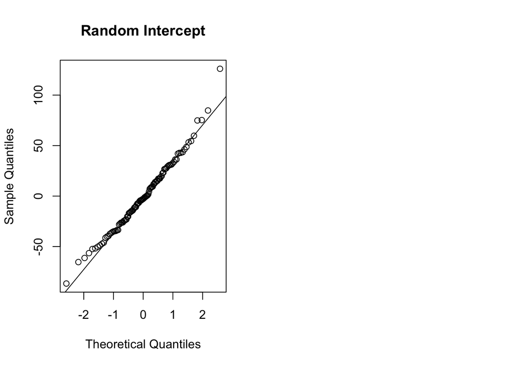

```r
#check assumptions
#assumotions check
# model_randomis<-lmer(stresslevel ~ week + (1+treatemnt|treatment),data=stress.long)
par (mfrow= c(1,2))
# Random Intercept
qqnorm(ranef(m0)$id[["(Intercept)"]],main="Random Intercept")
qqline(ranef(m0)$id[["(Intercept)"]])
#Residuals
par(mfrow=c(1,1))
```

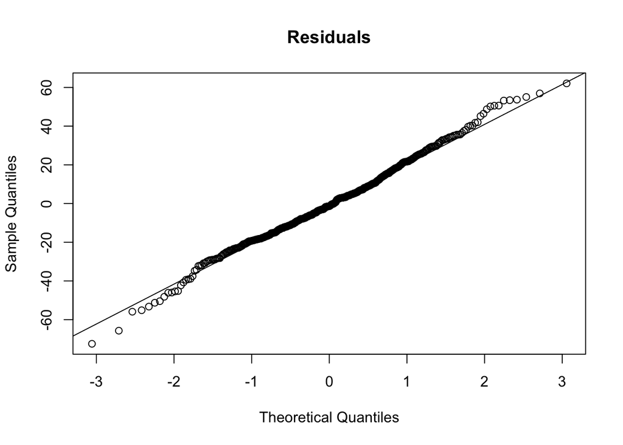

```r
Residuals<-residuals(m0)
qqnorm(Residuals,main="Residuals")
qqline(Residuals)
```

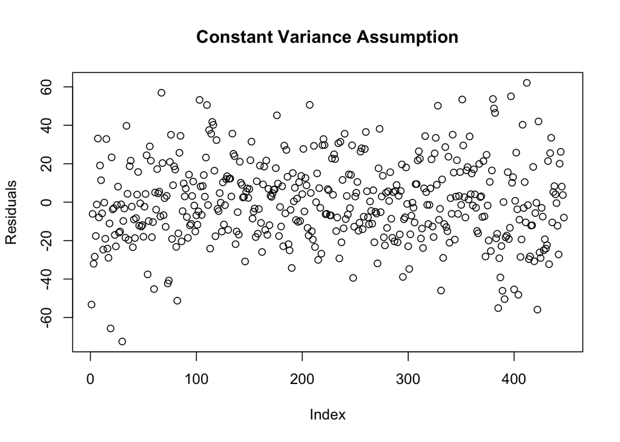

```r
#constant variance
plot(Residuals,main="Constant Variance Assumption")
```

so we choose m3 as new model.

Then compare m3 and m0.

The final model we choose is m0: lmer(choles~ treatment + month + (1|id), data = choles.long).

The independent, constant var and normal residuals all fit. So assumptions checked well.

2(h)

```r
#Let's try different variance-covariance matrices in lme
# ?corClasses   To find name for various correlation structures.
#corCompSymm  Compound symmetry
#corSymm      Unstructured
#corAR1       Autoregressive
#random intercept, no interaction
#Compound Symmetry
#default
m0.default = lme(value ~ id + variable, random = ~1|id, data = choles.long, na.action=na.omit)

m0.cor = lme(value ~ id + variable, random = ~1|id, data = choles.long, correlation=corCompSymm(), na.action=na.omit)
summary(m0.cor)
```

```
## Linear mixed-effects model fit by REML
##  Data: choles.long
##        AIC      BIC    logLik
##   4365.776 4390.351 -2176.888
##
## Random effects:
##  Formula: ~1 | id
##         (Intercept) Residual
## StdDev:    37.46455 24.05332
##
## Correlation Structure: Compound symmetry
##  Formula: ~1 | id
##  Parameter estimate(s):
## Rho
##   0
## Fixed effects: value ~ id + variable
##                 Value Std.Error  DF   t-value p-value
## (Intercept) 227.98072  8.156081 343 27.952237  0.0000
## id           -0.00936  0.130087 101 -0.071917  0.9428
## variable      6.56136  0.857771 343  7.649319  0.0000
##  Correlation:
##          (Intr) id
## id       -0.833
## variable -0.303  0.023
##
## Standardized Within-Group Residuals:
##         Min          Q1         Med          Q3         Max
## -3.01573267 -0.59560074 -0.05624081  0.56562144  2.57846611
##
## Number of Observations: 447
## Number of Groups: 103
```

```r
m0.AR1 = lme(value ~ id + variable, random = ~1|id, data = choles.long, correlation=corAR1(), na.action=na.omit)

# compare default to AR1 df5 vs df6
anova(m0.default,m0.AR1)
```

```
##            Model df      AIC      BIC    logLik   Test   L.Ratio p-value
## m0.default     1  5 4363.776 4384.256 -2176.888
## m0.AR1         2  6 4365.525 4390.100 -2176.763 1 vs 2 0.2510204  0.6164
```

```r
# compare default to cor df5 vs df6
anova(m0.default,m0.cor)
```

```
##            Model df      AIC      BIC    logLik   Test      L.Ratio
## m0.default     1  5 4363.776 4384.256 -2176.888
## m0.cor         2  6 4365.776 4390.351 -2176.888 1 vs 2 1.818989e-12
##            p-value
## m0.default
## m0.cor           1
```

```r
# Compound Symmetric Covariance Matrix
#Get icc
sd1 = 37.46455
sd2 = 24.05332

cov.mat = matrix(sd1^2, nrow = 5, ncol = 5)
diag(cov.mat) = sd1^2 + sd2^2
cov.mat
```

```
##          [,1]     [,2]     [,3]     [,4]     [,5]
## [1,] 1982.155 1403.593 1403.593 1403.593 1403.593
## [2,] 1403.593 1982.155 1403.593 1403.593 1403.593
## [3,] 1403.593 1403.593 1982.155 1403.593 1403.593
## [4,] 1403.593 1403.593 1403.593 1982.155 1403.593
## [5,] 1403.593 1403.593 1403.593 1403.593 1982.155
```

we reject this matrix because there is no significant improvement.

2(i)

```r
summary(m0.default)
```

```
## Linear mixed-effects model fit by REML
##  Data: choles.long
##        AIC      BIC    logLik
##   4363.776 4384.256 -2176.888
##
## Random effects:
##  Formula: ~1 | id
##         (Intercept) Residual
## StdDev:    37.46455 24.05332
##
## Fixed effects: value ~ id + variable
##                 Value Std.Error  DF   t-value p-value
## (Intercept) 227.98072  8.156081 343 27.952237  0.0000
## id           -0.00936  0.130087 101 -0.071917  0.9428
## variable      6.56136  0.857771 343  7.649319  0.0000
##  Correlation:
##          (Intr) id
## id       -0.833
## variable -0.303  0.023
##
## Standardized Within-Group Residuals:
##         Min          Q1         Med          Q3         Max
## -3.01573267 -0.59560074 -0.05624081  0.56562144  2.57846611
##
## Number of Observations: 447
## Number of Groups: 103
```

3 bounus

```r
cats = read.csv("~/downloads/cats.csv")
attach(cats)
head(cats)
```

```
##   id weight age gender environment origin treatment visit.1 visit.2
## 1  1    4.0  15      1           1      1         1       8       9
## 2  2    4.0  67      1           1      2         0       9       9
## 3  3    6.0  55      1           1      1         1       9      11
## 4  4    3.5  78      2           1      1         0       9       9
## 5  5    6.2  50      1           2      3         1      10      10
## 6  6    2.0  10      2           2      4         0       6       6
##   visit.3 visit.4 visit.5
## 1       8       9       9
## 2       9       9       9
## 3      12      13      16
## 4       9       9       9
## 5      10      10      10
## 6       6       6       6
```

```r
cats.long= reshape(cats, direction="long",idvar="id", vary=c("visit.1","visit.2","visit.3","visit.4","visit.5"))
cats.long$stress= cats.long$visit
head(cats.long)
```

```
##     id weight age gender environment origin treatment time visit stress
## 1.1  1    4.0  15      1           1      1         1    1     8      8
## 2.1  2    4.0  67      1           1      2         0    1     9      9
## 3.1  3    6.0  55      1           1      1         1    1     9      9
## 4.1  4    3.5  78      2           1      1         0    1     9      9
## 5.1  5    6.2  50      1           2      3         1    1    10     10
## 6.1  6    2.0  10      2           2      4         0    1     6      6
```

```r
cats.long$gender= as.factor(cats.long$gender)
cats.long$environment= as.factor(cats.long$environment)
cats.long$origin= as.factor(cats.long$origin)
cats.long$treatment= as.factor(cats.long$treatment)
#Random Intercept
model1= lmer(stress ~ weight + age + gender + environment + origin + treatment + time + (1|id), data=cats.long)
summary(model1)
```

```
## Linear mixed model fit by REML. t-tests use Satterthwaite's method [
## lmerModLmerTest]
## Formula:
## stress ~ weight + age + gender + environment + origin + treatment +
##     time + (1 | id)
##    Data: cats.long
##
## REML criterion at convergence: 748.5
##
## Scaled residuals:
##     Min      1Q  Median      3Q     Max
## -3.1529 -0.5321  0.0019  0.6780  2.2283
##
## Random effects:
##  Groups   Name        Variance Std.Dev.
##  id       (Intercept) 10.639   3.262
##  Residual              3.295   1.815
## Number of obs: 170, groups:  id, 34
##
## Fixed effects:
##                Estimate Std. Error         df t value Pr(>|t|)
## (Intercept)    1.177738   3.222487  22.374027   0.365  0.71819
## weight         0.945585   0.509804  22.000000   1.855  0.07708 .
## age           -0.008551   0.019966  22.000000  -0.428  0.67263
## gender2        2.544118   1.606494  22.000000   1.584  0.12755
## gender3        0.951348   3.070956  22.000000   0.310  0.75964
## environment2  -1.274599   1.470093  22.000000  -0.867  0.39529
## origin2        2.989185   1.995677  22.000000   1.498  0.14839
## origin3       -1.972152   3.830501  22.000000  -0.515  0.61179
## origin4        0.996738   2.562505  22.000000   0.389  0.70104
## origin5        3.035528   1.684584  22.000000   1.802  0.08527 .
## origin6        8.362662   2.727772  22.000000   3.066  0.00566 **
## treatment1     3.730971   1.396917  22.000000   2.671  0.01396 *
## time           0.967647   0.098446 135.000000   9.829  < 2e-16 ***
## ---
## Signif. codes:  0 '***' 0.001 '**' 0.01 '*' 0.05 '.' 0.1 ' ' 1
```

```
##
## Correlation matrix not shown by default, as p = 13 > 12.
## Use print(x, correlation=TRUE)  or
##     vcov(x)        if you need it
```

```r
#Random Slope - Correlated Intercept and Slope
model2= lmer(stress ~ weight + age + gender + environment + origin + treatment + time + (1 + time|id), data=cats.long)
summary(model2)
```

```
## Linear mixed model fit by REML. t-tests use Satterthwaite's method [
## lmerModLmerTest]
## Formula:
## stress ~ weight + age + gender + environment + origin + treatment +
##     time + (1 + time | id)
##    Data: cats.long
##
## REML criterion at convergence: 687.2
##
## Scaled residuals:
##      Min       1Q   Median       3Q      Max
## -2.98812 -0.23826  0.00892  0.31160  2.57151
##
## Random effects:
##  Groups   Name        Variance Std.Dev. Corr
##  id       (Intercept) 12.3717  3.5173
##           time         0.8126  0.9014   -0.44
##  Residual              1.3088  1.1440
## Number of obs: 170, groups:  id, 34
##
## Fixed effects:
##               Estimate Std. Error        df t value Pr(>|t|)
## (Intercept)   2.540646   3.090465 22.451861   0.822   0.4197
## weight        0.793942   0.488375 21.998304   1.626   0.1183
## age          -0.005612   0.019127 21.998304  -0.293   0.7719
## gender2       2.214564   1.538966 21.998304   1.439   0.1642
## gender3       1.421145   2.941869 21.998304   0.483   0.6338
## environment2 -1.402558   1.408298 21.998304  -0.996   0.3301
## origin2       3.189175   1.911789 21.998304   1.668   0.1095
## origin3      -0.389624   3.669487 21.998304  -0.106   0.9164
## origin4       0.292719   2.454791 21.998304   0.119   0.9062
## origin5       2.761736   1.613773 21.998304   1.711   0.1011
## origin6       6.960316   2.613111 21.998304   2.664   0.0142 *
## treatment1    2.761235   1.338198 21.998304   2.063   0.0511 .
## time          0.967647   0.166580 33.000120   5.809 1.69e-06 ***
## ---
## Signif. codes:  0 '***' 0.001 '**' 0.01 '*' 0.05 '.' 0.1 ' ' 1
```

```
##
## Correlation matrix not shown by default, as p = 13 > 12.
## Use print(x, correlation=TRUE)  or
##     vcov(x)        if you need it
```

```r
anova(model1,model2)
```

```
## refitting model(s) with ML (instead of REML)
```

```
## Data: cats.long
## Models:
## model1: stress ~ weight + age + gender + environment + origin + treatment +
## model1:     time + (1 | id)
## model2: stress ~ weight + age + gender + environment + origin + treatment +
## model2:     time + (1 + time | id)
##        Df    AIC    BIC  logLik deviance  Chisq Chi Df Pr(>Chisq)
## model1 15 795.97 843.00 -382.98   765.97
## model2 17 738.62 791.93 -352.31   704.62 61.346      2  4.774e-14 ***
## ---
## Signif. codes:  0 '***' 0.001 '**' 0.01 '*' 0.05 '.' 0.1 ' ' 1
```

```r
#Random Slope - Uncorrelated Intercept and Slope
model3= lmer(stress ~ weight + age + gender + environment + origin + treatment + time + (1|id) + (0 + time|id), data=cats.long)
summary(model3)
```

```
## Linear mixed model fit by REML. t-tests use Satterthwaite's method [
## lmerModLmerTest]
## Formula:
## stress ~ weight + age + gender + environment + origin + treatment +
##     time + (1 | id) + (0 + time | id)
##    Data: cats.long
##
## REML criterion at convergence: 690.5
##
## Scaled residuals:
##      Min       1Q   Median       3Q      Max
## -3.07707 -0.32573  0.00196  0.33271  2.52610
##
## Random effects:
##  Groups   Name        Variance Std.Dev.
##  id       (Intercept) 10.7568  3.2798
##  id.1     time         0.7594  0.8715
##  Residual              1.3333  1.1547
## Number of obs: 170, groups:  id, 34
##
## Fixed effects:
##              Estimate Std. Error       df t value Pr(>|t|)
## (Intercept)   4.36948    3.31394 21.87655   1.319   0.2010
## weight        0.59046    0.52636 21.85355   1.122   0.2741
## age          -0.00167    0.02062 21.85355  -0.081   0.9362
## gender2       1.77235    1.65867 21.85355   1.069   0.2969
## gender3       2.05155    3.17070 21.85355   0.647   0.5243
## environment2 -1.57426    1.51784 21.85355  -1.037   0.3110
## origin2       3.45753    2.06049 21.85355   1.678   0.1076
## origin3       1.73391    3.95491 21.85355   0.438   0.6654
## origin4      -0.65198    2.64573 21.85355  -0.246   0.8077
## origin5       2.39434    1.73930 21.85355   1.377   0.1826
## origin6       5.07856    2.81637 21.85355   1.803   0.0852 .
## treatment1    1.45998    1.44229 21.85355   1.012   0.3225
## time          0.96765    0.16204 33.39227   5.972    1e-06 ***
## ---
## Signif. codes:  0 '***' 0.001 '**' 0.01 '*' 0.05 '.' 0.1 ' ' 1
```

```
##
## Correlation matrix not shown by default, as p = 13 > 12.
## Use print(x, correlation=TRUE)  or
##     vcov(x)        if you need it
```

```r
anova(model2,model3)
```

```
## refitting model(s) with ML (instead of REML)
```

```
## Data: cats.long
## Models:
## model3: stress ~ weight + age + gender + environment + origin + treatment +
## model3:     time + (1 | id) + (0 + time | id)
## model2: stress ~ weight + age + gender + environment + origin + treatment +
## model2:     time + (1 + time | id)
##        Df    AIC    BIC  logLik deviance  Chisq Chi Df Pr(>Chisq)
## model3 16 741.67 791.85 -354.84   709.67
## model2 17 738.62 791.93 -352.31   704.62 5.0519      1     0.0246 *
## ---
## Signif. codes:  0 '***' 0.001 '**' 0.01 '*' 0.05 '.' 0.1 ' ' 1
```

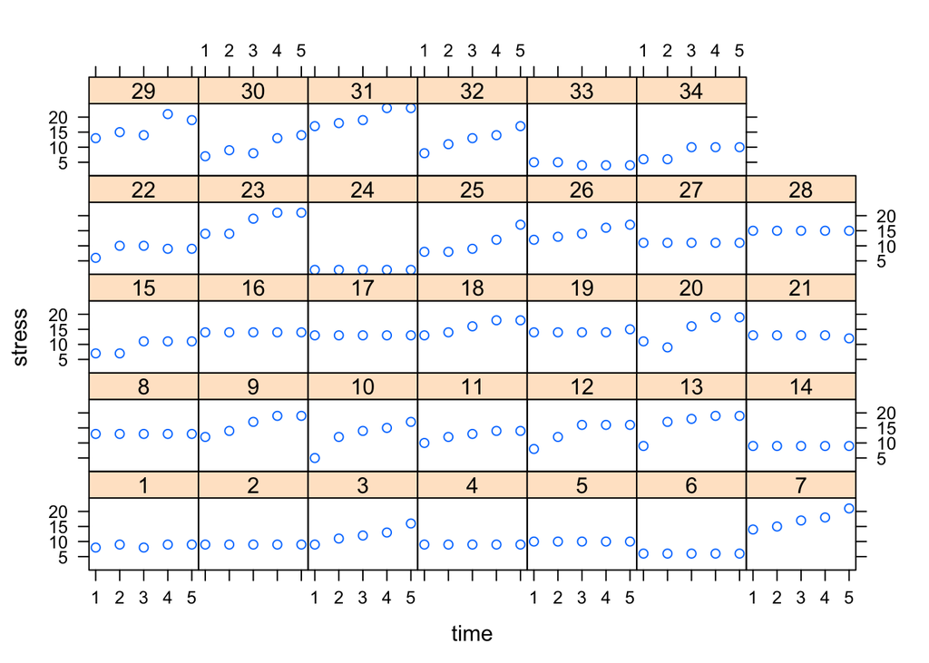

```r
xyplot(stress ~ time|as.factor(id), data=cats.long)
```

```r
anova(model2)
```

```
## Type III Analysis of Variance Table with Satterthwaite's method
##             Sum Sq Mean Sq NumDF  DenDF F value    Pr(>F)
## weight       3.459   3.459     1 21.998  2.6428   0.11826
## age          0.113   0.113     1 21.998  0.0861   0.77195
## gender       2.717   1.358     2 21.998  1.0378   0.37094
## environment  1.298   1.298     1 21.998  0.9919   0.33012
## origin      12.649   2.530     5 21.998  1.9329   0.12947
## treatment    5.572   5.572     1 21.998  4.2576   0.05107 .
## time        44.164  44.164     1 33.000 33.7433 1.694e-06 ***
## ---
## Signif. codes:  0 '***' 0.001 '**' 0.01 '*' 0.05 '.' 0.1 ' ' 1
```

Among all the variables we know the time in cat.long is significant because the p value is significant.